# R Notebook

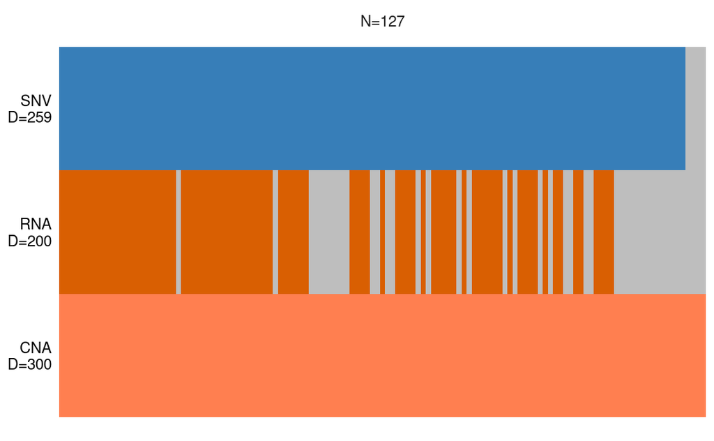

### View Model Options

```r
MOFAobject@data_options
```

```
$loaded
[1] TRUE

$views
[1] "CNA" "RNA" "SNV"

$groups
[1] "single_group"
```

```r
MOFAobject@model_options
```

```
$ard_factors
[1] FALSE

$ard_weights
[1] TRUE

$likelihoods
       CNA        RNA        SNV
"gaussian" "gaussian" "gaussian"

$spikeslab_factors
[1] FALSE

$spikeslab_weights
[1] TRUE
```

```r
MOFAobject@training_options
```

```
$maxiter
[1] 1000

$freqELBO
[1] 5

$start_elbo
[1] 1

$gpu_mode
[1] 0

$stochastic
[1] 0

$seed
[1] 42
```

# Correlation between factors, variance decomposition by factor, total variance explained across views

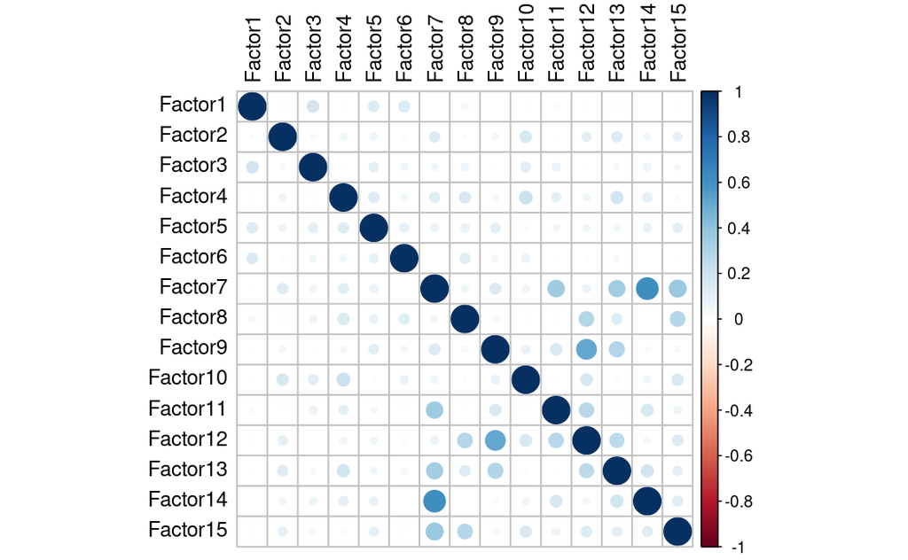

```r
plot_factor_cor(MOFAobject)
```

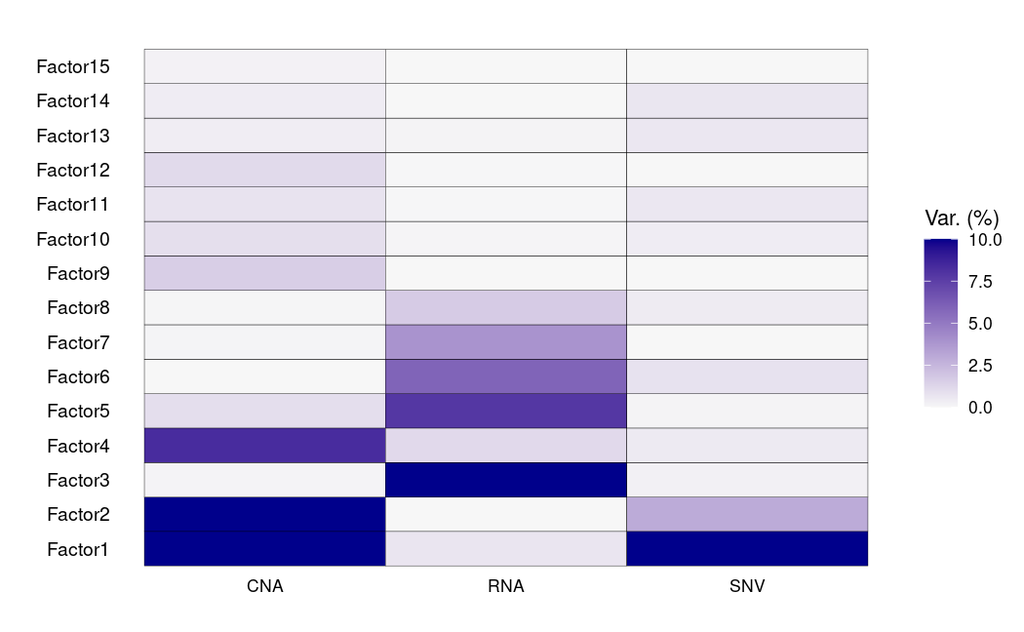

```r
plot_variance_explained(MOFAobject, max_r2=10)
```

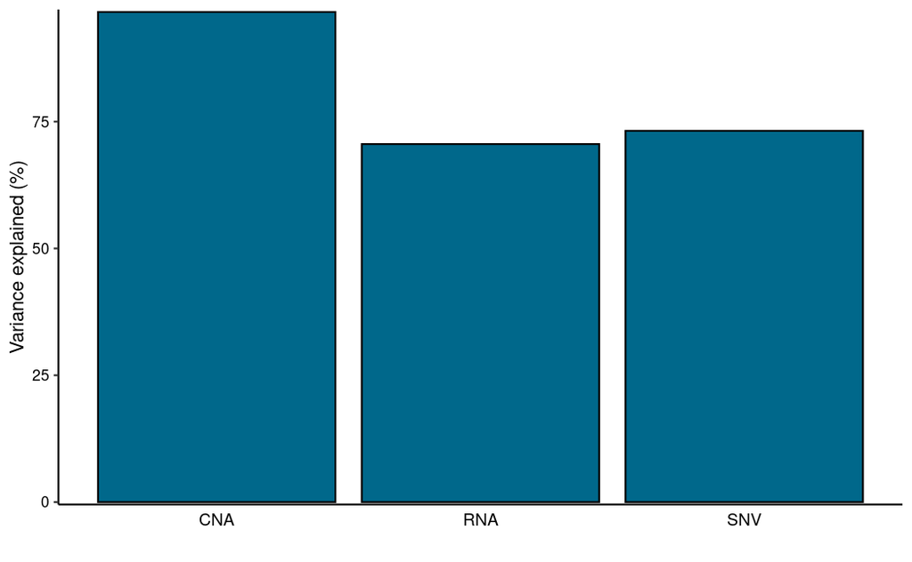

```r
plot_variance_explained(MOFAobject, plot_total = T)[[2]]
```

### apply meta data

```r
samples_metadata(MOFAobject) <- met
```

# Association between MOFA factors and meta data

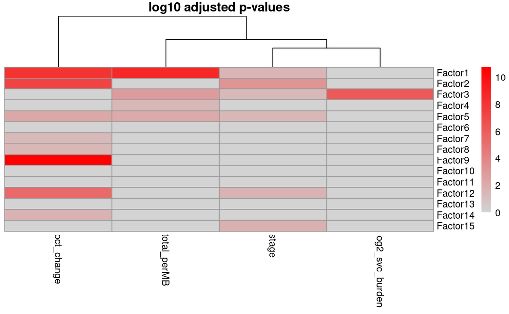

```r
correlate_factors_with_covariates(MOFAobject,
  covariates = c("total_perMB","stage", "log2_svc_burden", "pct_change"),
  plot="log_pval"
)
```

# Factor 1 Analysis - CNA and SNV views were the only views to explain variance

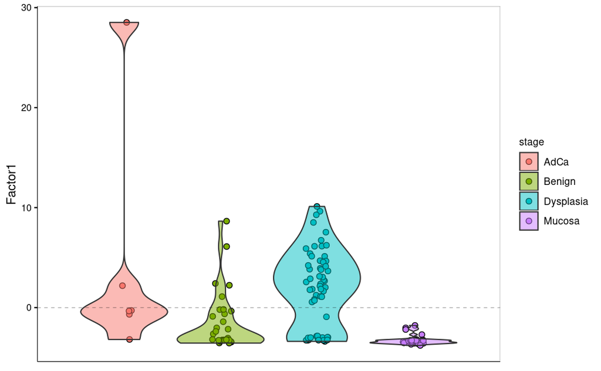

```r
plot_factor(MOFAobject,
  factors = 1,
  color_by = "stage",
  add_violin = TRUE,
  dodge = TRUE
)
```

### Factor 1 top weighted genes (features) via SNV view

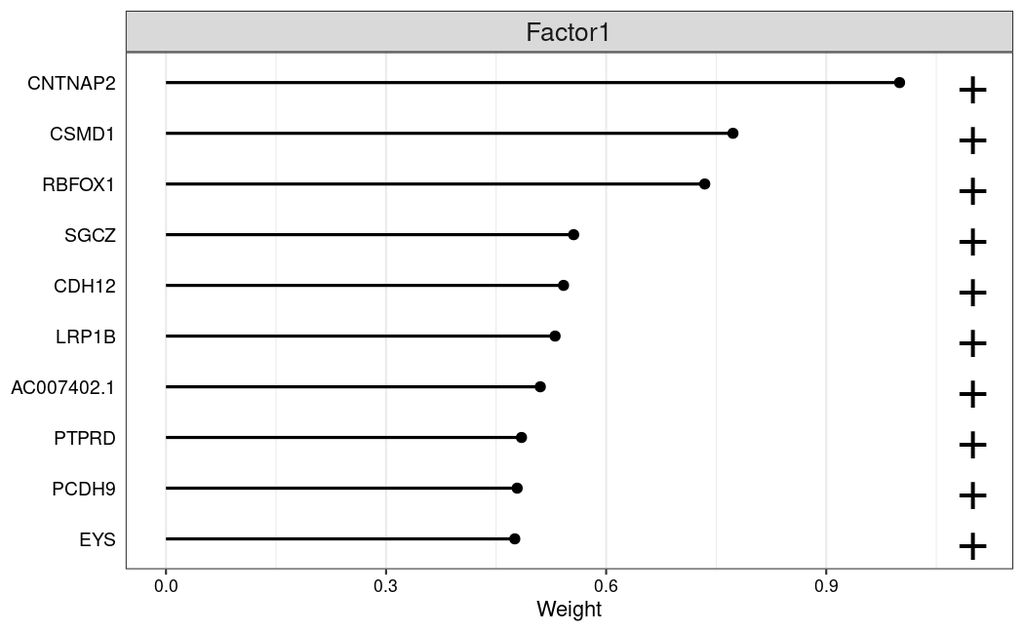

```r
plot_top_weights(MOFAobject,
 view = "SNV",
 factor = 1,
 nfeatures = 10,     # Top number of features to highlight
 scale = T           # Scale weights from -1 to 1
)
```

### Linear progression from Normal Mucosa -> Benign -> dysplasia -> one adenocarcinoma sample (colored by stage)

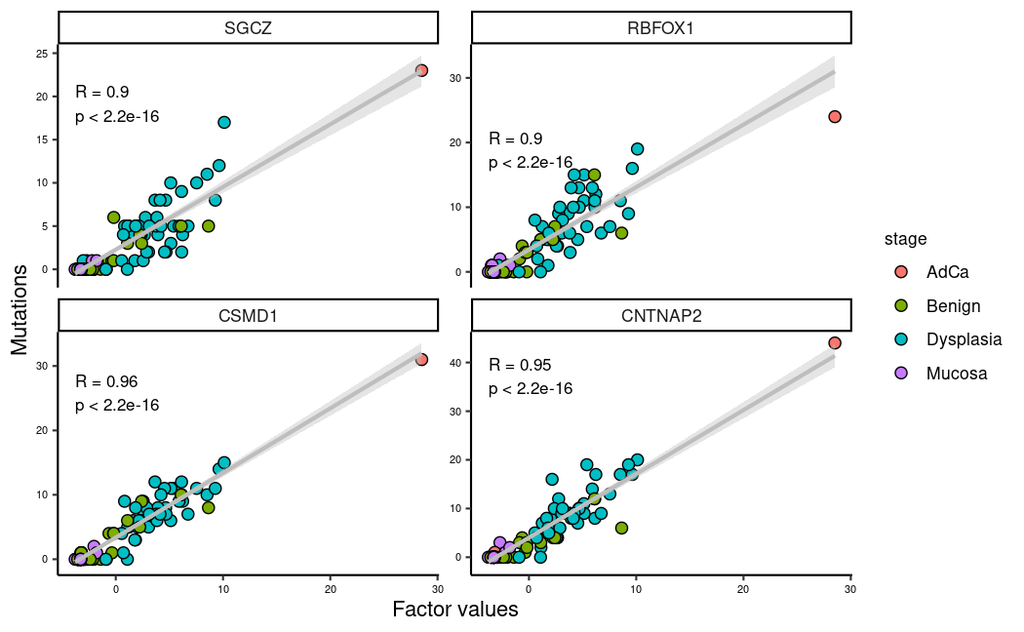

```r
plot_data_scatter(MOFAobject,
  view = "SNV",
  factor = 1,
  features = 4,
  sign = "positive",
  color_by = "stage"
) + labs(y="Mutations")
```

### CNA view factor 1 top weighted genes

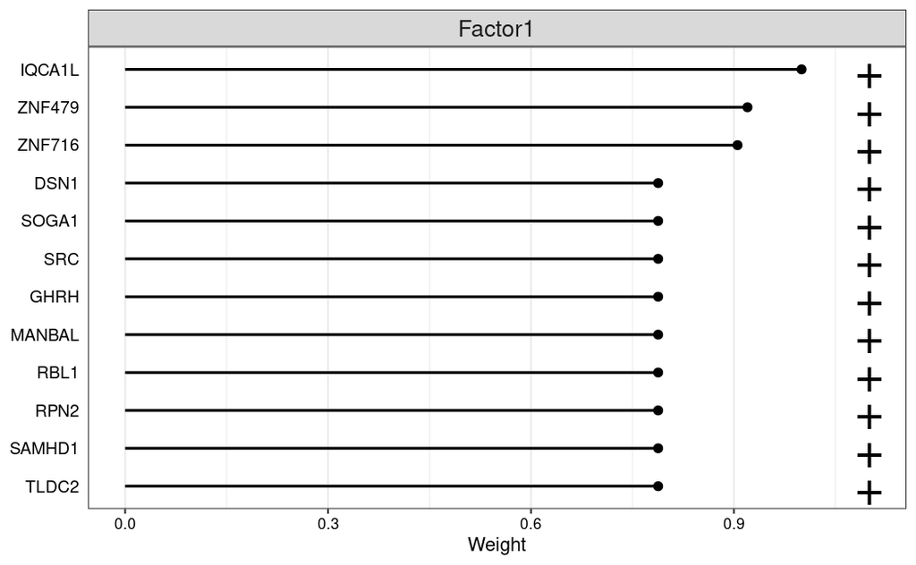

```r
plot_top_weights(MOFAobject,
 view = "CNA",
 factor = 1,
 nfeatures = 10,     # Top number of features to highlight
 scale = T           # Scale weights from -1 to 1
)
```

### CNA view factor 1: Factor 1 sample values vs 4 top weighted genes

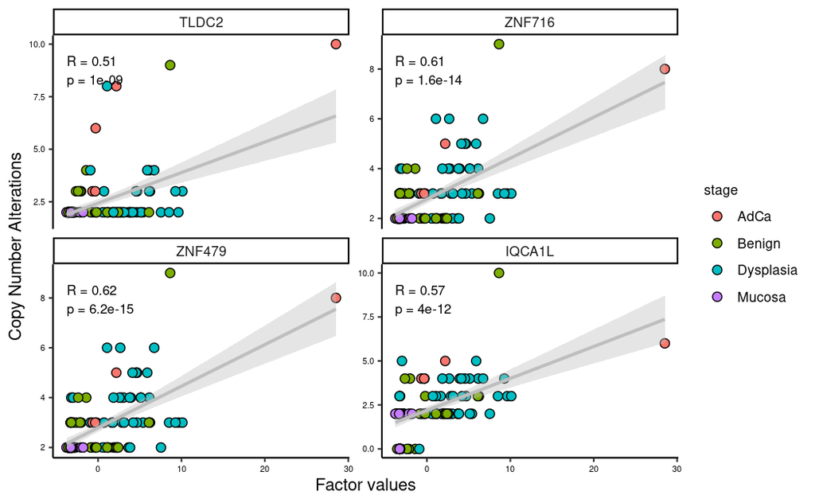

```r
plot_data_scatter(MOFAobject,
  view = "CNA",
  factor = 1,
  features = 4,
  sign = "positive",
  color_by = "stage"
) + labs(y="Copy Number Alterations")
```

# Factor 2 Analysis - CNA and SNV views were the only views to explain variance

### Factor 2 top weighted genes CNA view

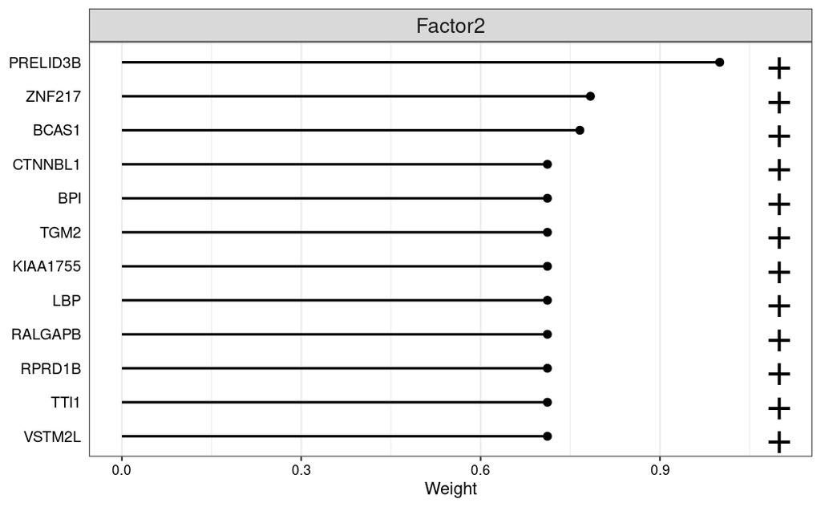

```r
plot_top_weights(MOFAobject,
 view = "CNA",
 factor = 2,
 nfeatures = 10,     # Top number of features to highlight
 scale = T           # Scale weights from -1 to 1
)
```

### CNA view factor 2: Factor 2 sample values vs top 4 top weighted genes for CNA view (colored by stage)

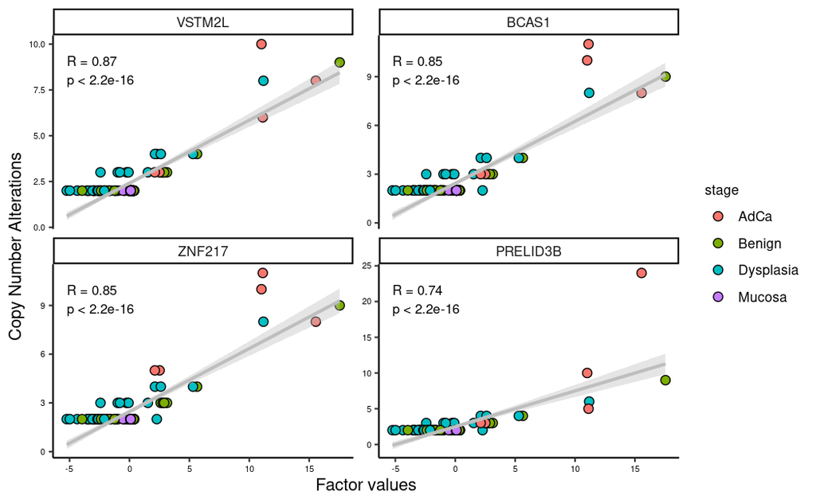

```r
plot_data_scatter(MOFAobject,
  view = "CNA",
  factor = 2,
  features = 4,
  sign = "positive",
  color_by = "stage"
) + labs(y="Copy Number Alterations")
```

### SNV view factor 2: Factor 2 sample values vs top 4 top weighted genes for SNV view (colored by stage)

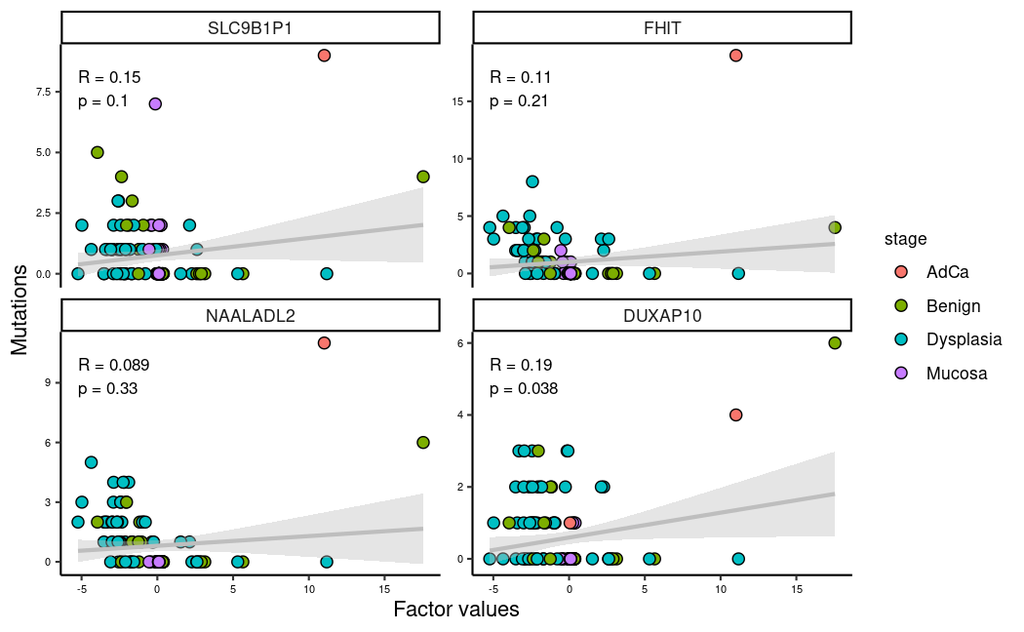

```r
plot_data_scatter(MOFAobject,
  view = "SNV",
  factor = 2,
  features = 4,
  sign = "positive",
  color_by = "stage"
) + labs(y="Mutations")
```

# Factor 3 Analysis - RNA view was the only view that explained variance

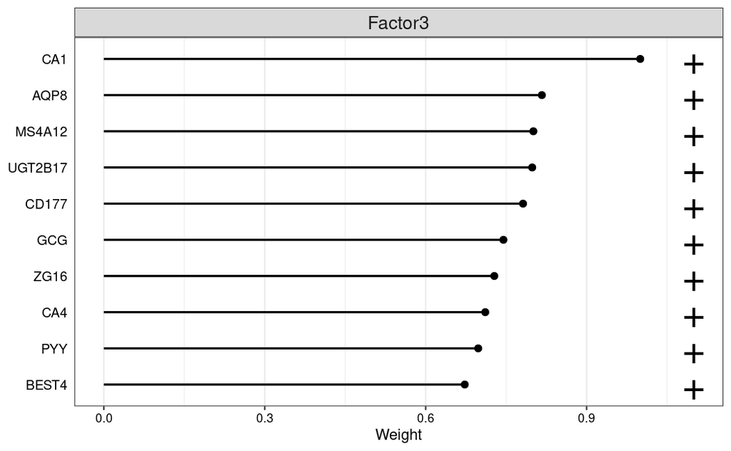

```r
plot_top_weights(MOFAobject,
 view = "RNA",
 factor = 3,
 nfeatures = 10,     # Top number of features to highlight
 scale = T           # Scale weights from -1 to 1
)
```

### RNA view factor 3: Factor 3 sample values vs top 4 top weighted genes for RNA view (colored by stage)

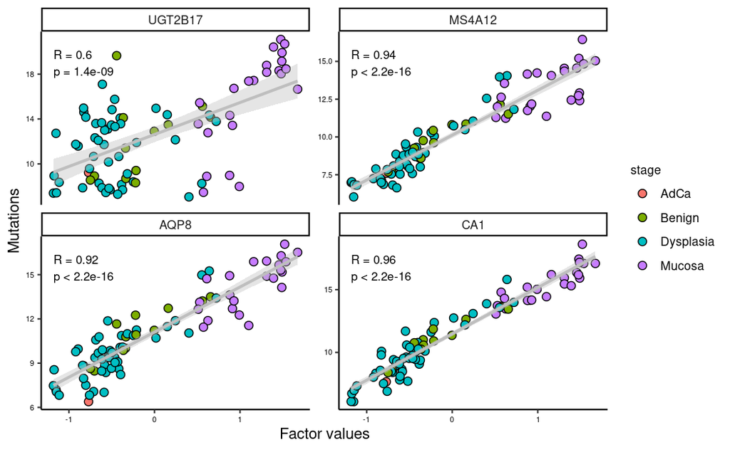

```r
plot_data_scatter(MOFAobject,
  view = "RNA",
  factor = 3,
  features = 4,
  sign = "positive",
  color_by = "stage"
) + labs(y="Mutations")
```

### Factor 3 heat map for RNA view

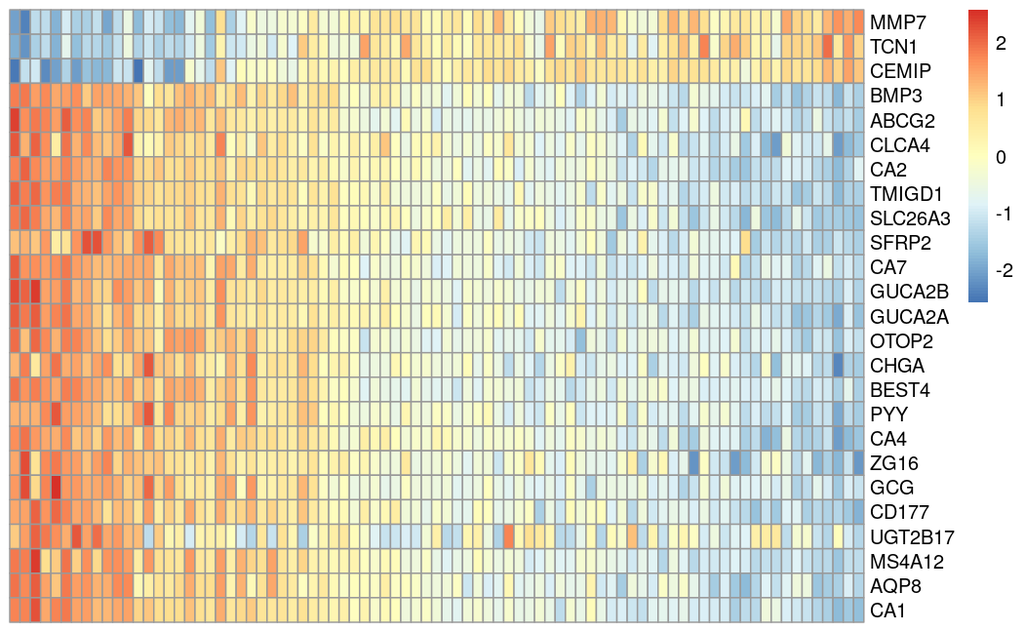

```r
plot_data_heatmap(MOFAobject,
  view = "RNA",
  factor = 3,
  features = 25,
  cluster_rows = FALSE, cluster_cols = FALSE,
  show_rownames = TRUE, show_colnames = F,
  scale = "row"
)
```

# Factor 5 downstream analysis

### top weighted genes for factor 5 (RNA views)

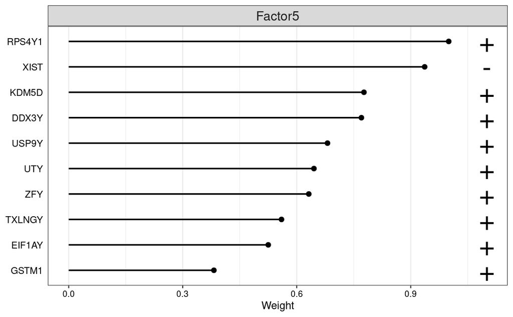

```r
plot_top_weights(MOFAobject,
 view = "RNA",
 factor = 5,
 nfeatures = 10,     # Top number of features to highlight
 scale = T           # Scale weights from -1 to 1
)
```

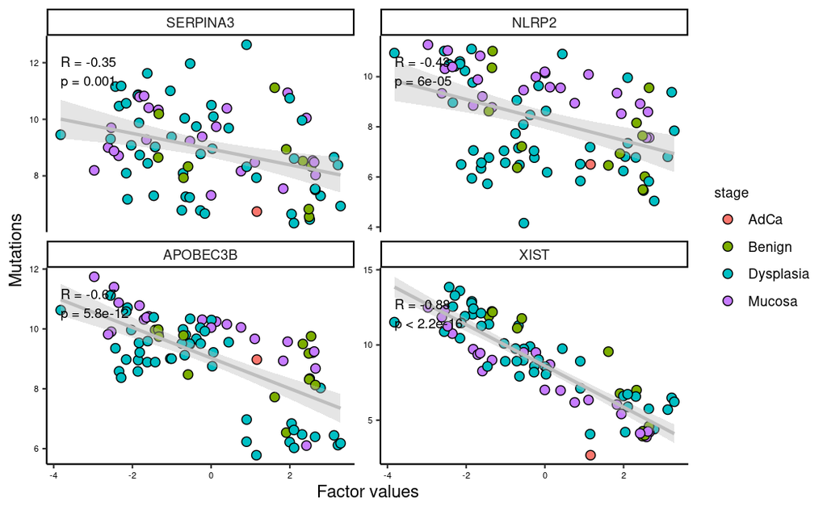

```r
plot_data_scatter(MOFAobject,
  view = "RNA",
  factor = 5,
  features = 4,
  sign = "negative",
  color_by = "stage"
) + labs(y="Mutations")
```

# Combination of factors analysis

### Factor 1 and 2

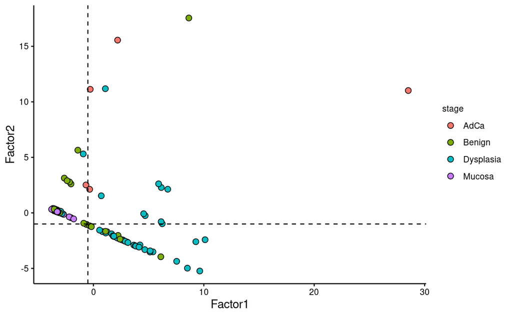

```r
p <- plot_factors(MOFAobject,
  factors = c(1,2),
  color_by = "stage",
  #shape_by = "CSMD1",
  dot_size = 2.5,
  show_missing = T
)

p <- p +
  geom_hline(yintercept=-1, linetype="dashed") +
  geom_vline(xintercept=(-0.5), linetype="dashed")

print(p)
```

### Factors 1 and 3 combination plot - subsects the dysplasia data well

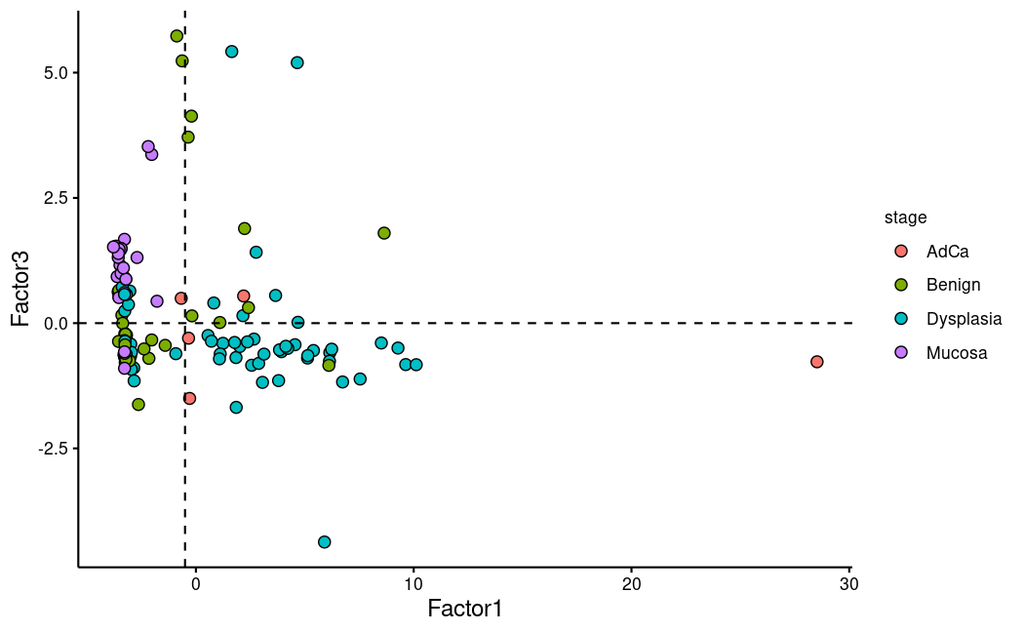

```r
p <- plot_factors(MOFAobject,
  factors = c(1,3),
  color_by = "stage",
  #shape_by = "CSMD1",
  dot_size = 2.5,
  show_missing = T
)

p <- p +
  geom_hline(yintercept=-0, linetype="dashed") +
  geom_vline(xintercept=(-0.5), linetype="dashed")

print(p)
```

### Factors 1 and 3 combination plot - shaped by mutations in the CSMD1 gene

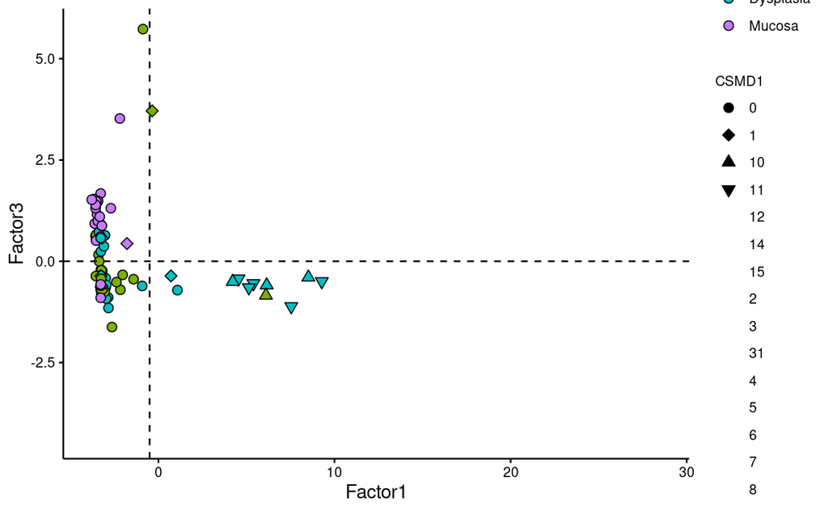

```r
p <- plot_factors(MOFAobject,
  factors = c(1,3),
  color_by = "stage",
  shape_by = "CSMD1", # CSMD1 is a top weighted gene in snv view
  dot_size = 2.5,
  show_missing = T
)

p <- p +
  geom_hline(yintercept=-0, linetype="dashed") +
  geom_vline(xintercept=(-0.5), linetype="dashed")

print(p)
```

### Factors 2 and 3 combination plot - subsects the dysplasia data well

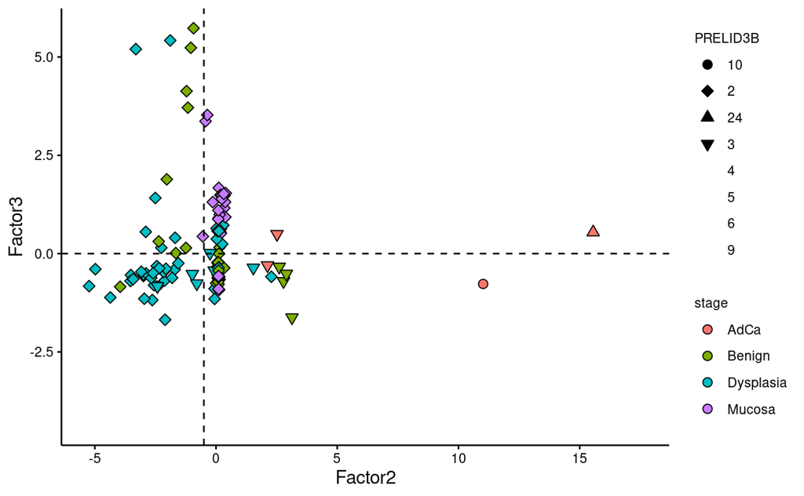

```r
p <- plot_factors(MOFAobject,
  factors = c(2,3),
  color_by = "stage",
  shape_by = "PRELID3B",
  dot_size = 2.5,
  show_missing = T
)

p <- p +
  geom_hline(yintercept=-0, linetype="dashed") +
  geom_vline(xintercept=(-0.5), linetype="dashed")

print(p)
```

# Get pathways associated with the top weighted genes of factors 1,2,3 through the SNV, CNA, and RNA view respectivley

```r
SNV_weights <- get_weights( MOFAobject, views = "SNV", factors = 1, abs = FALSE, scale=FALSE,
                            as.data.frame =FALSE)
CNA_weights <- get_weights( MOFAobject, views = "CNA", factors = 2, abs = FALSE, scale=FALSE,
                            as.data.frame =FALSE)
RNA_weights <- get_weights(MOFAobject, views = "RNA", factors =3, abs = FALSE, scale = FALSE,
                           as.data.frame = FALSE)
```

### Write the 30 top weighted SNV genes into a file - factor 1

```r
df_SNV <- as.data.frame(SNV_weights)
df_SNV <- cbind(gene = rownames(df_SNV), df_SNV)

df_SNV <- df_SNV[order(-df_SNV$Factor1),]
writeLines(df_SNV$gene[1:30], "top_30_SNV.txt")
```

### Write the 30 top weighted CNA genes into a file - factor 2

```r
df_CNA <- as.data.frame(CNA_weights)
df_CNA <- cbind(gene = rownames(df_CNA), df_CNA)
df_CNA <- df_CNA[order(-df_CNA$Factor2),]
df_CNA
```

|  | gene | Factor2 |
| --- | --- | --- |
| PRELID3B | PRELID3B | 0.47037645 |
| ZNF217 | ZNF217 | 0.36863624 |
| BCAS1 | BCAS1 | 0.36032048 |
| CTNNBL1 | CTNNBL1 | 0.33478491 |
| BPI | BPI | 0.33478491 |
| TGM2 | TGM2 | 0.33478491 |
| KIAA1755 | KIAA1755 | 0.33478491 |
| LBP | LBP | 0.33478491 |
| RALGAPB | RALGAPB | 0.33478491 |
| RPRD1B | RPRD1B | 0.33478491 |

[output cut: 290 more lines]

```r
writeLines(df_CNA$gene[1:30], "top_30_CNA.txt")
```

```r
df_RNA <- as.data.frame(RNA_weights)
df_RNA<- cbind(gene = rownames(df_RNA), df_RNA)
df_RNA <- df_RNA[order(-df_RNA$Factor3),]
df_RNA
```

|  | gene | Factor3 |
| --- | --- | --- |
| CA1 | CA1 | 3.671642914 |
| AQP8 | AQP8 | 2.998258608 |
| MS4A12 | MS4A12 | 2.940081526 |
| UGT2B17 | UGT2B17 | 2.932256677 |
| CD177 | CD177 | 2.869485646 |
| GCG | GCG | 2.735119777 |
| ZG16 | ZG16 | 2.672634671 |
| CA4 | CA4 | 2.610785397 |
| PYY | PYY | 2.562520184 |
| BEST4 | BEST4 | 2.470417820 |

[output cut: 190 more lines]

```r
writeLines(df_RNA$gene[1:30], "top_30_RNA.txt")
```

# The top 30 genes of each view were pasted in to https://maayanlab.cloud/Enrichr/ to get associated wikipathways